# mpdw

NIda Khairunnissa

2025-08-19

# Pengenalan Data

### Input Data

```r
# impor data
library(rio)
```

```r
data <- import("https://raw.githubusercontent.com/nida-kha44/MPDW/refs/heads/main/Pertemuan%201/btc_historical_price.csv")
head(data)
```

```
##         date price
## 1 2011-01-01 0.300
## 2 2011-01-02 0.300
## 3 2011-01-03 0.295
## 4 2011-01-04 0.299
## 5 2011-01-05 0.299
## 6 2011-01-06 0.298
```

```r
summary(data)
```

```
##       date                price
##  Min.   :2011-01-01   Min.   :    0.3
##  1st Qu.:2013-10-31   1st Qu.:  198.8
##  Median :2016-08-30   Median :  712.7
##  Mean   :2016-08-30   Mean   : 8171.6
##  3rd Qu.:2019-06-30   3rd Qu.: 8601.2
##  Max.   :2022-04-30   Max.   :67544.9
```

```r
# mengambil baris 1655 - 2485 hasil pembagian dengan teman kelompok
btcprice <- data[1655:2485, ]
head(btcprice)
```

```
##            date    price
## 1655 2015-07-13 290.8811
## 1656 2015-07-14 286.1856
## 1657 2015-07-15 283.8231
## 1658 2015-07-16 277.8273
## 1659 2015-07-17 278.4883
## 1660 2015-07-18 274.4938
```

### Eksplorasi Data

```r
View(btcprice) # melihat data
str(btcprice)  # mengetahui struktur data
```

```
## 'data.frame':    831 obs. of  2 variables:
##  $ date : IDate, format: "2015-07-13" "2015-07-14" ...
##  $ price: num  291 286 284 278 278 ...
```

```r
dim(btcprice)  # mengetahui dimensi data
```

```
## [1] 831   2
```

```r
summary(btcprice) # menampilkan ringkasan data
```

```
##       date                price
##  Min.   :2015-07-13   Min.   : 209.1
##  1st Qu.:2016-02-05   1st Qu.: 417.7
##  Median :2016-08-31   Median : 635.5
##  Mean   :2016-08-31   Mean   :1144.0
##  3rd Qu.:2017-03-26   3rd Qu.:1184.8
##  Max.   :2017-10-20   Max.   :5984.1
```

```r
# mengubah data agar menjadi data deret waktu
btcprice.ts <- ts(btcprice$price)
summary(btcprice.ts)
```

```
##    Min. 1st Qu.  Median    Mean 3rd Qu.    Max.
##   209.1   417.7   635.5  1144.0  1184.8  5984.1
```

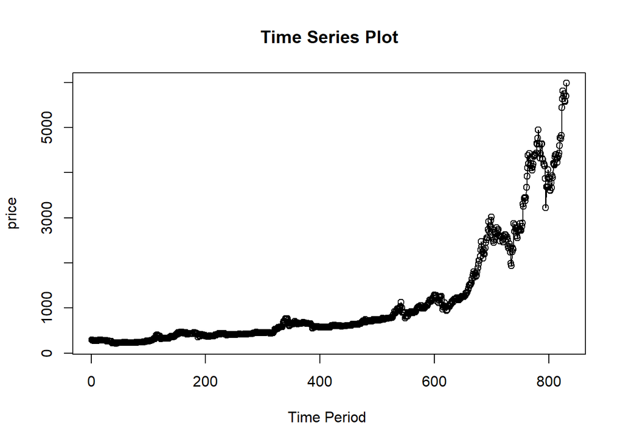

```r
# membuat plot data deret waktu
ts.plot(btcprice.ts, xlab="Time Period ", ylab="price",
        main = "Time Series Plot")
points(btcprice.ts)
```

Dari plot di atas, dapat terlihat bahwa data memiliki pola Non-linear upward trend (eksponensial) dengan volatilitas meningkat. Akan dilakukan pemulusan dengan metode Exponential Smoothing.

## Exponential Smoothing

Metode *Exponential Smoothing* adalah metode pemulusan dengan melakukan pembobotan menurun secara eksponensial. Nilai yang lebih baru diberi bobot yang lebih besar dari nilai terdahulu. Terdapat satu atau lebih parameter pemulusan yang ditentukan secara eksplisit, dan hasil pemilihan parameter tersebut akan menentukan bobot yang akan diberikan pada nilai pengamatan. Ada dua macam model, yaitu model tunggal dan ganda.

### Pembagian Data

Pembagian data latih dan data uji dilakukan dengan perbandingan 80% data latih dan 20% data uji.

```r
#membagi training dan testing
training <- btcprice[1:664, ]
testing <- btcprice[665:831, ]
train.ts <- ts(training$price)
test.ts <- ts(testing$price)
```

### Eksplorasi

Eksplorasi dilakukan dengan membuat plot data deret waktu untuk keseluruhan data, data latih, dan data uji.

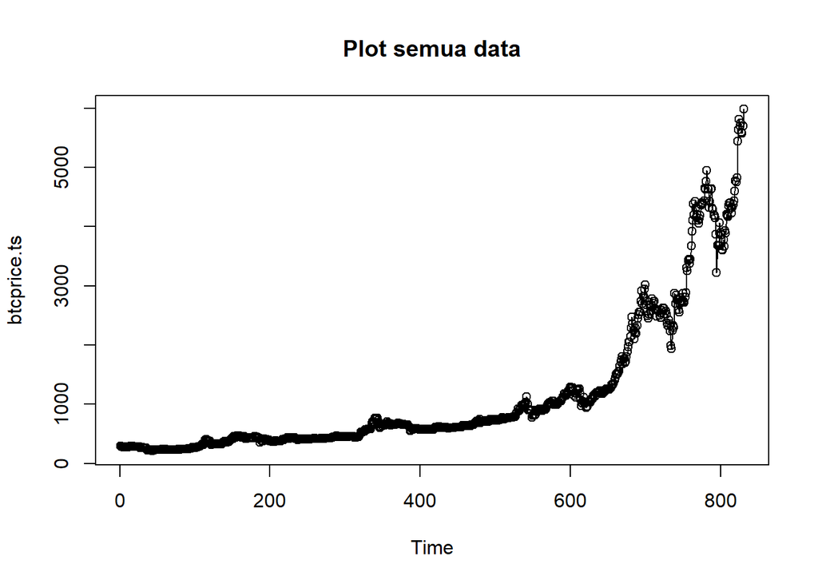

```r
#eksplorasi data
plot(btcprice.ts, col="black",main="Plot semua data")
points(btcprice.ts)
```

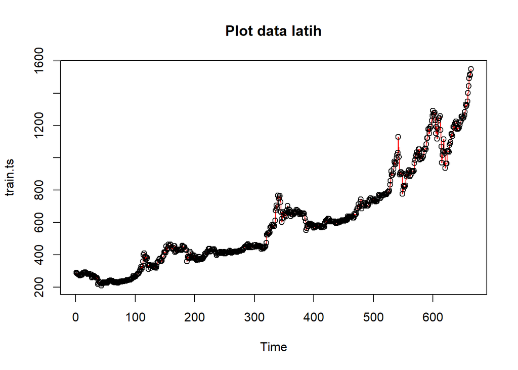

```r
plot(train.ts, col="red",main="Plot data latih")
points(train.ts)
```

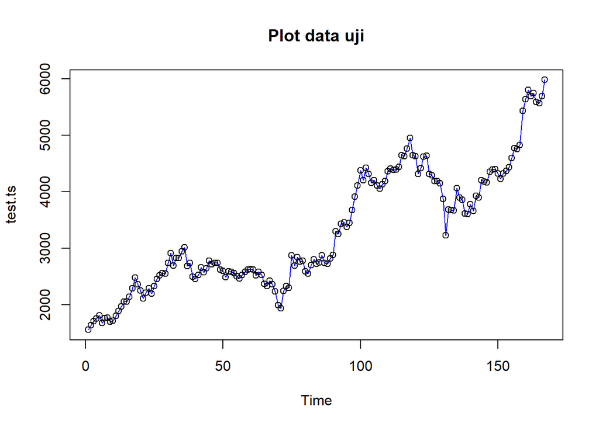

```r
plot(test.ts, col="blue",main="Plot data uji")
points(test.ts)
```

### DES

Metode pemulusan *Double Exponential Smoothing* (DES) digunakan untuk data yang memiliki pola tren. Metode DES adalah metode semacam SES, hanya saja dilakukan dua kali, yaitu pertama untuk tahapan ‘level’ dan kedua untuk tahapan ‘tren’. Pemulusan menggunakan metode ini akan menghasilkan peramalan tidak konstan untuk periode berikutnya.

Pemulusan dengan metode DES kali ini akan menggunakan fungsi `HoltWinters()` . Jika sebelumnya nilai argumen `beta` dibuat `FALSE` , kali ini argumen tersebut akan diinisialisasi bersamaan dengan nilai `alpha` .

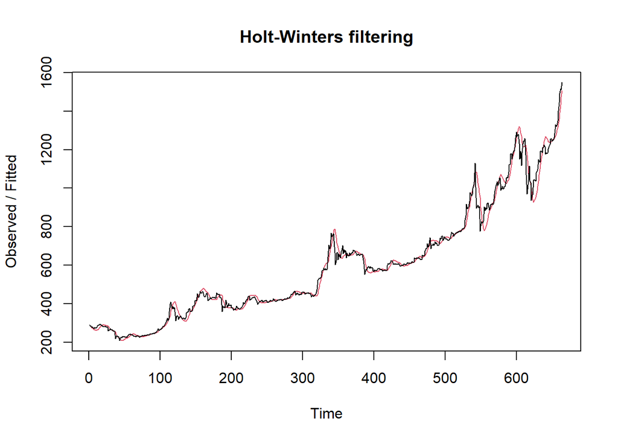

```r
#Lamda=0.2 dan gamma=0.2
des.1<- HoltWinters(train.ts, gamma = FALSE, beta = 0.2, alpha = 0.2)
plot(des.1)
```

```r
#ramalan
library(forecast)
ramalandes1<- forecast(des.1, h=167)
ramalandes1
```

```
##     Point Forecast    Lo 80    Hi 80    Lo 95    Hi 95
## 665       1540.995 1495.368 1586.622 1471.214 1610.776
## 666       1567.805 1520.882 1614.728 1496.043 1639.567
## 667       1594.615 1545.984 1643.246 1520.241 1668.990
## 668       1621.425 1570.650 1672.201 1543.771 1699.080
## 669       1648.236 1594.869 1701.602 1566.619 1729.852
## 670       1675.046 1618.645 1731.446 1588.788 1761.303
## 671       1701.856 1641.989 1761.723 1610.297 1793.415
## 672       1728.666 1664.918 1792.414 1631.173 1826.160
## 673       1755.476 1687.456 1823.496 1651.449 1859.503
## 674       1782.286 1709.626 1854.947 1671.162 1893.411
## 675       1809.097 1731.450 1886.743 1690.346 1927.847
## 676       1835.907 1752.951 1918.863 1709.036 1962.777
## 677       1862.717 1774.148 1951.285 1727.263 1998.171
## 678       1889.527 1795.062 1983.992 1745.056 2033.999
```

[output cut: 153 more lines]

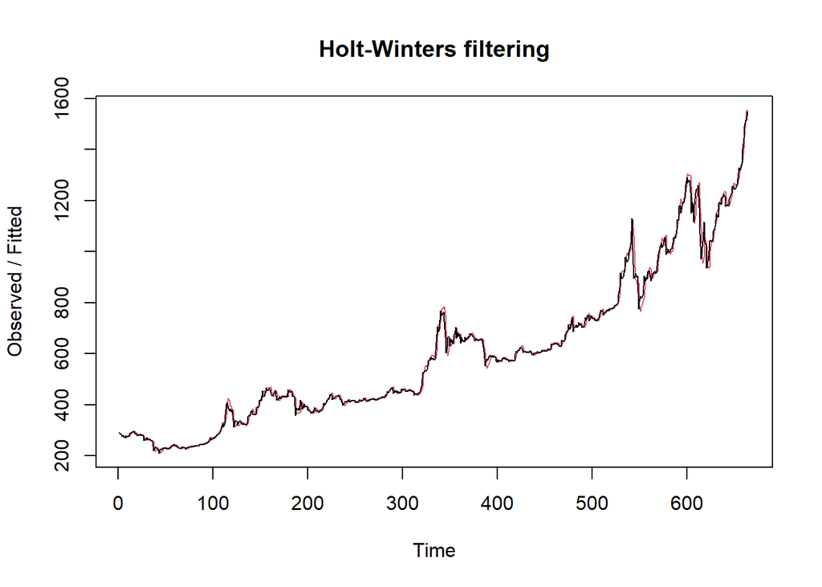

```r
#Lamda=0.6 dan gamma=0.3
des.2<- HoltWinters(train.ts, gamma = FALSE, beta = 0.3, alpha = 0.6)
plot(des.2)
```

```r
#ramalan
ramalandes2<- forecast(des.2, h=167)
ramalandes2
```

```
##     Point Forecast      Lo 80     Hi 80        Lo 95     Hi 95
## 665       1578.010 1547.40963  1608.611  1531.210699  1624.810
## 666       1604.990 1566.18148  1643.798  1545.637564  1664.342
## 667       1631.970 1583.29653  1680.643  1557.530560  1706.409
## 668       1658.949 1599.06612  1718.833  1567.365845  1750.533
## 669       1685.929 1613.69635  1758.162  1575.458644  1796.400
## 670       1712.909 1627.32584  1798.492  1582.020943  1843.797
## 671       1739.889 1640.05212  1839.725  1587.201893  1892.575
## 672       1766.868 1651.94723  1881.789  1591.111687  1942.625
## 673       1793.848 1663.06679  1924.629  1593.835374  1993.861
## 674       1820.828 1673.45532  1968.200  1595.441044  2046.215
## 675       1847.808 1683.14954  2012.466  1595.984855  2099.630
## 676       1874.787 1692.18046  2057.394  1595.514255  2154.060
## 677       1901.767 1700.57483  2102.959  1594.070111  2209.464
## 678       1928.747 1708.35600  2149.138  1591.688183  2265.805
```

[output cut: 153 more lines]

Selanjutnya ingin dibandingkan plot data latih dan data uji adalah sebagai berikut.

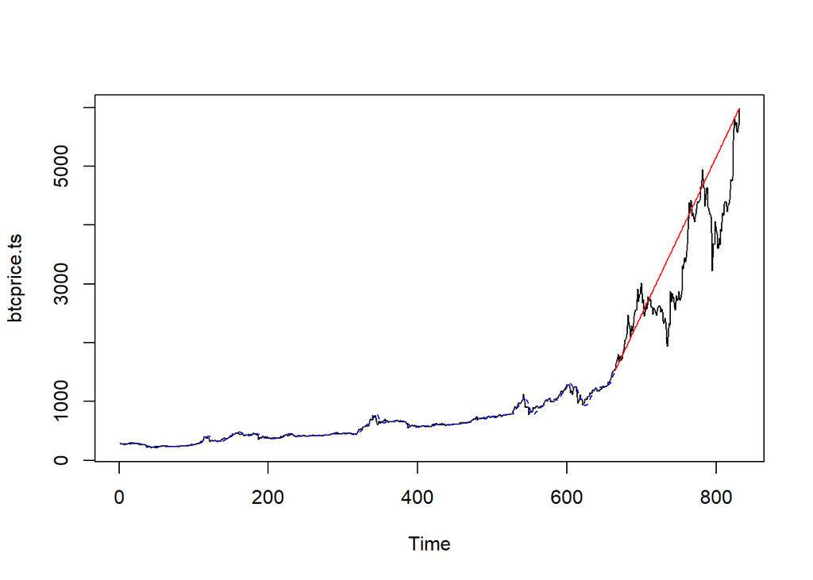

```r
#Visually evaluate the prediction
plot(btcprice.ts)
lines(des.1$fitted[,1], lty=2, col="blue")
lines(ramalandes1$mean, col="red")
```

Untuk mendapatkan nilai parameter optimum dari DES, argumen `alpha` dan `beta` dapat dibuat `NULL` seperti berikut.

```r
#Lamda dan gamma optimum
des.opt<- HoltWinters(train.ts, gamma = FALSE)
des.opt
```

```
## Holt-Winters exponential smoothing with trend and without seasonal component.
##
## Call:
## HoltWinters(x = train.ts, gamma = FALSE)
##
## Smoothing parameters:
##  alpha: 1
##  beta : 0.01120346
##  gamma: FALSE
##
## Coefficients:
##          [,1]
## a 1548.286300
## b    5.759443
```

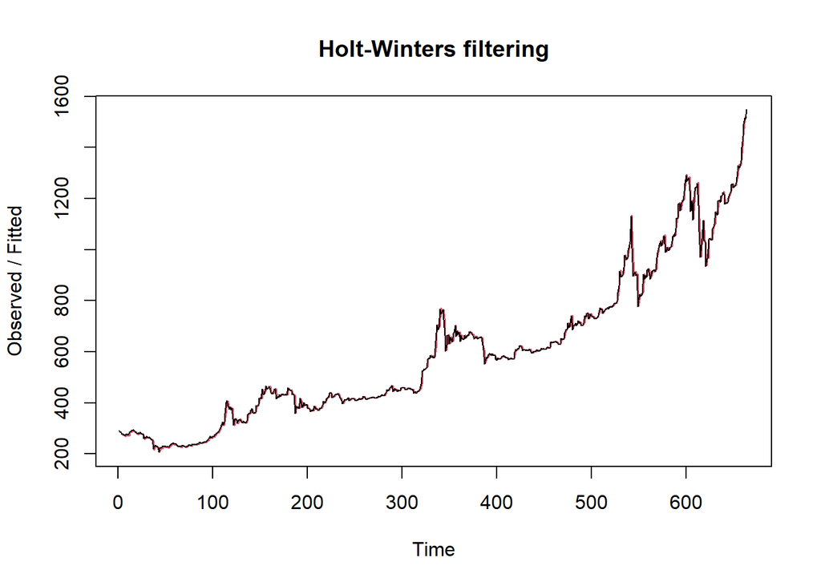

```r
plot(des.opt)
```

```r
#ramalan
ramalandesopt<- forecast(des.opt, h=167)
ramalandesopt
```

```
##     Point Forecast    Lo 80    Hi 80    Lo 95    Hi 95
## 665       1554.046 1527.222 1580.869 1513.023 1595.069
## 666       1559.805 1521.658 1597.952 1501.464 1618.146
## 667       1565.565 1518.583 1612.547 1493.712 1637.417
## 668       1571.324 1516.771 1625.877 1487.893 1654.755
## 669       1577.084 1515.753 1638.414 1483.287 1670.880
## 670       1582.843 1515.287 1650.399 1479.525 1686.161
## 671       1588.602 1515.232 1661.973 1476.392 1700.813
## 672       1594.362 1515.495 1673.229 1473.745 1714.979
## 673       1600.121 1516.013 1684.230 1471.488 1728.755
## 674       1605.881 1516.739 1695.022 1469.551 1742.211
## 675       1611.640 1517.641 1705.640 1467.880 1755.400
## 676       1617.400 1518.689 1716.110 1466.435 1768.364
## 677       1623.159 1519.865 1726.453 1465.184 1781.134
## 678       1628.919 1521.150 1736.687 1464.101 1793.736
```

[output cut: 153 more lines]

Selanjutnya akan dilakukan perhitungan akurasi pada data latih maupun data uji dengan ukuran akurasi SSE, MSE dan MAPE.

#### Akurasi Data Latih

```r
#Akurasi Data Training
ssedes.train1<-des.1$SSE
msedes.train1<-ssedes.train1/length(train.ts)
sisaandes1<-ramalandes1$residuals
head(sisaandes1)
```

```
## Time Series:
## Start = 1
## End = 6
## Frequency = 1
## [1]       NA       NA 2.333000 0.472780 5.622493 4.861863
```

```r
mapedes.train1 <- sum(abs(sisaandes1[3:length(train.ts)]/train.ts[3:length(train.ts)])
                      *100)/length(train.ts)

akurasides.1 <- matrix(c(ssedes.train1,msedes.train1,mapedes.train1))
row.names(akurasides.1)<- c("SSE", "MSE", "MAPE")
colnames(akurasides.1) <- c("Akurasi lamda=0.2 dan gamma=0.2")
akurasides.1
```

```
##      Akurasi lamda=0.2 dan gamma=0.2
## SSE                     8.388072e+05
## MSE                     1.263264e+03
## MAPE                    3.291585e+00
```

```r
ssedes.train2<-des.2$SSE
msedes.train2<-ssedes.train2/length(train.ts)
sisaandes2<-ramalandes2$residuals
head(sisaandes2)
```

```
## Time Series:
## Start = 1
## End = 6
## Frequency = 1
## [1]        NA        NA  2.333000 -0.787040  4.763411  1.470678
```

```r
mapedes.train2 <- sum(abs(sisaandes2[3:length(train.ts)]/train.ts[3:length(train.ts)])
                      *100)/length(train.ts)

akurasides.2 <- matrix(c(ssedes.train2,msedes.train2,mapedes.train2))
row.names(akurasides.2)<- c("SSE", "MSE", "MAPE")
colnames(akurasides.2) <- c("Akurasi lamda=0.6 dan gamma=0.3")
akurasides.2
```

```
##      Akurasi lamda=0.6 dan gamma=0.3
## SSE                     3.769123e+05
## MSE                     5.676390e+02
## MAPE                    2.094042e+00
```

Hasil pemulusan time series menunjukkan bahwa model dengan parameter λ = 0.6 dan γ = 0.3 memiliki performa yang lebih baik dibandingkan dengan model λ = 0.2 dan γ = 0.2. Hal ini terlihat dari nilai SSE, MSE, dan MAPE yang lebih kecil, yaitu masing-masing sebesar 376,912; 567; dan 2.09%. Sementara itu, model pertama menghasilkan nilai kesalahan yang lebih besar, yaitu SSE = 838,807; MSE = 1,263; dan MAPE = 3.29%. Dengan demikian, dapat disimpulkan bahwa model dengan λ = 0.6 dan γ = 0.3 lebih sesuai digunakan untuk meramalkan data karena memberikan tingkat akurasi yang lebih tinggi.

#### Akurasi Data Uji

```r
# Akurasi Data Uji
# Cek dan sesuaikan panjang dulu
common_length <- min(length(ramalandes1$mean), length(testing$price))

# Akurasi Data Testing - FIXED
selisihdes1 <- ramalandes1$mean[1:common_length] - testing$price[1:common_length]
SSEtestingdes1 <- sum(selisihdes1^2)
MSEtestingdes1 <- SSEtestingdes1/common_length
MAPEtestingdes1 <- sum(abs(selisihdes1/testing$price[1:common_length])*100)/common_length

selisihdes2 <- ramalandes2$mean[1:common_length] - testing$price[1:common_length]
SSEtestingdes2 <- sum(selisihdes2^2)
MSEtestingdes2 <- SSEtestingdes2/common_length
MAPEtestingdes2 <- sum(abs(selisihdes2/testing$price[1:common_length])*100)/common_length

selisihdesopt <- ramalandesopt$mean[1:common_length] - testing$price[1:common_length]
SSEtestingdesopt <- sum(selisihdesopt^2)
MSEtestingdesopt <- SSEtestingdesopt/common_length
MAPEtestingdesopt <- sum(abs(selisihdesopt/testing$price[1:common_length])*100)/common_length

# Buat matrix akurasi
akurasitestingdes <- matrix(
  c(SSEtestingdes1, MSEtestingdes1, MAPEtestingdes1,
    SSEtestingdes2, MSEtestingdes2, MAPEtestingdes2,
    SSEtestingdesopt, MSEtestingdesopt, MAPEtestingdesopt),
  nrow = 3, ncol = 3, byrow = FALSE
)

row.names(akurasitestingdes) <- c("SSE", "MSE", "MAPE")
colnames(akurasitestingdes) <- c("des ske1", "des ske2", "des opt")

print(akurasitestingdes)
```

```
##          des ske1     des ske2      des opt
## SSE  9.023515e+07 9.939989e+07 3.873175e+08
## MSE  5.403302e+05 5.952089e+05 2.319266e+06
## MAPE 1.783127e+01 1.864297e+01 3.447167e+01
```

#### Peramalan

```r
#Forecast
forecast1 <- predict(des.1, n.ahead = 167)
forecast2 <- predict(des.2, n.ahead = 167)
forecast.opt <- predict(des.opt, n.ahead = 167)
```

#### Plot Deret Waktu

```r
library(forecast)

# Misalnya meramalkan 10 periode ke depan
horizon <- 200

# Forecast dengan horizon baru (future forecasting)
forecast_des1 <- forecast(ramalandes1$model, h = horizon)
forecast_des2 <- forecast(ramalandes2$model, h = horizon)
forecast_desopt <- forecast(ramalandesopt$model, h = horizon)

# Lihat hasil peramalan
forecast_des1
```

```
##     Point Forecast    Lo 80    Hi 80    Lo 95     Hi 95
## 665       1540.995 1495.368 1586.622 1471.214  1610.776
## 666       1567.805 1520.882 1614.728 1496.043  1639.567
## 667       1594.615 1545.984 1643.246 1520.241  1668.990
## 668       1621.425 1570.650 1672.201 1543.771  1699.080
## 669       1648.236 1594.869 1701.602 1566.619  1729.852
## 670       1675.046 1618.645 1731.446 1588.788  1761.303
## 671       1701.856 1641.989 1761.723 1610.297  1793.415
## 672       1728.666 1664.918 1792.414 1631.173  1826.160
## 673       1755.476 1687.456 1823.496 1651.449  1859.503
## 674       1782.286 1709.626 1854.947 1671.162  1893.411
## 675       1809.097 1731.450 1886.743 1690.346  1927.847
## 676       1835.907 1752.951 1918.863 1709.036  1962.777
## 677       1862.717 1774.148 1951.285 1727.263  1998.171
## 678       1889.527 1795.062 1983.992 1745.056  2033.999
```

[output cut: 186 more lines]

```r
forecast_des2
```

```
##     Point Forecast       Lo 80     Hi 80        Lo 95     Hi 95
## 665       1578.010  1547.40963  1608.611  1531.210699  1624.810
## 666       1604.990  1566.18148  1643.798  1545.637564  1664.342
## 667       1631.970  1583.29653  1680.643  1557.530560  1706.409
## 668       1658.949  1599.06612  1718.833  1567.365845  1750.533
## 669       1685.929  1613.69635  1758.162  1575.458644  1796.400
## 670       1712.909  1627.32584  1798.492  1582.020943  1843.797
## 671       1739.889  1640.05212  1839.725  1587.201893  1892.575
## 672       1766.868  1651.94723  1881.789  1591.111687  1942.625
## 673       1793.848  1663.06679  1924.629  1593.835374  1993.861
## 674       1820.828  1673.45532  1968.200  1595.441044  2046.215
## 675       1847.808  1683.14954  2012.466  1595.984855  2099.630
## 676       1874.787  1692.18046  2057.394  1595.514255  2154.060
## 677       1901.767  1700.57483  2102.959  1594.070111  2209.464
## 678       1928.747  1708.35600  2149.138  1591.688183  2265.805
```

[output cut: 186 more lines]

```r
forecast_desopt
```

```
##     Point Forecast    Lo 80    Hi 80    Lo 95    Hi 95
## 665       1554.046 1527.222 1580.869 1513.023 1595.069
## 666       1559.805 1521.658 1597.952 1501.464 1618.146
## 667       1565.565 1518.583 1612.547 1493.712 1637.417
## 668       1571.324 1516.771 1625.877 1487.893 1654.755
## 669       1577.084 1515.753 1638.414 1483.287 1670.880
## 670       1582.843 1515.287 1650.399 1479.525 1686.161
## 671       1588.602 1515.232 1661.973 1476.392 1700.813
## 672       1594.362 1515.495 1673.229 1473.745 1714.979
## 673       1600.121 1516.013 1684.230 1471.488 1728.755
## 674       1605.881 1516.739 1695.022 1469.551 1742.211
## 675       1611.640 1517.641 1705.640 1467.880 1755.400
## 676       1617.400 1518.689 1716.110 1466.435 1768.364
## 677       1623.159 1519.865 1726.453 1465.184 1781.134
## 678       1628.919 1521.150 1736.687 1464.101 1793.736
```

[output cut: 186 more lines]

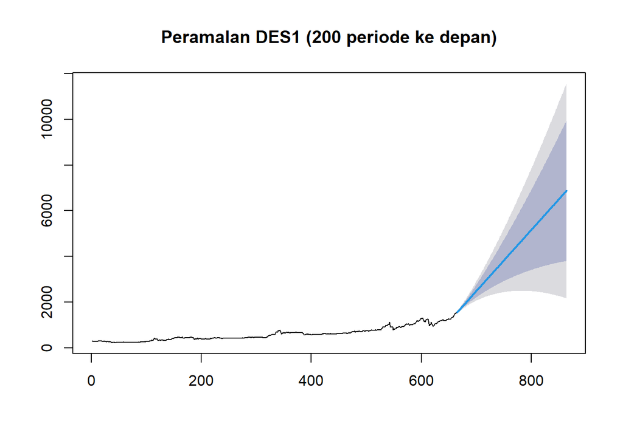

```r
# Plot hasil peramalan
plot(forecast_des1, main = "Peramalan DES1 (200 periode ke depan)")
```

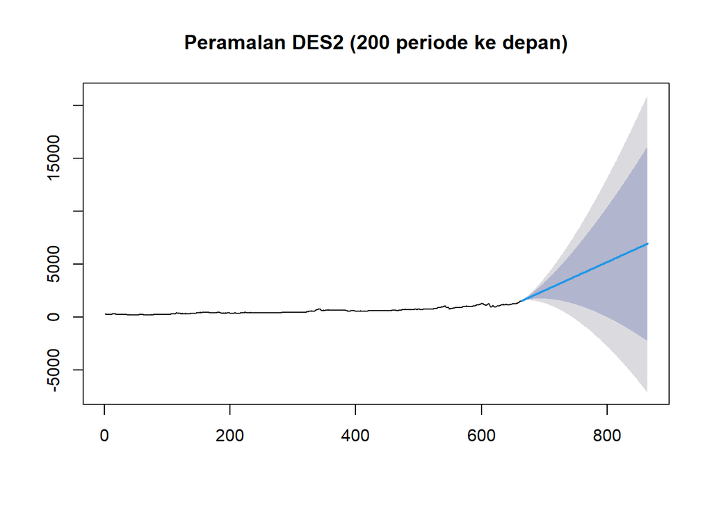

```r
plot(forecast_des2, main = "Peramalan DES2 (200 periode ke depan)")
```

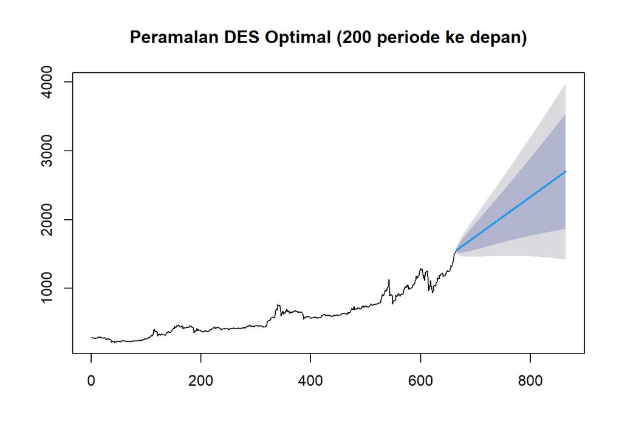

```r
plot(forecast_desopt, main = "Peramalan DES Optimal (200 periode ke depan)")
```

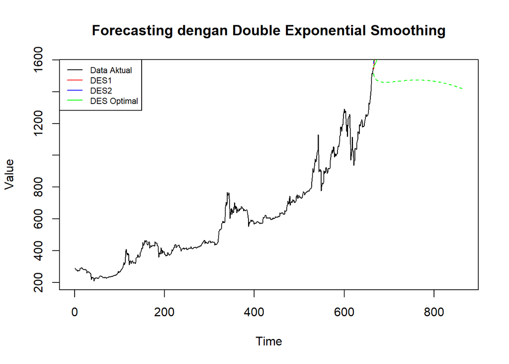

```r
# Plot data aktual (training)
plot(train.ts, main="Forecasting dengan Double Exponential Smoothing",
     type="l", col="black", xlim=c(1, length(train.ts) + horizon),
     xlab="Time", ylab="Value")

# Tambahkan hasil ramalan
lines(forecast_des1$mean, col="red", lty=1)
lines(forecast_des2$mean, col="blue", lty=1)
lines(forecast_desopt$mean, col="green", lty=1)

# (Opsional) Tambahkan interval prediksi model terbaik
lines(forecast_desopt$lower[,2], col="green", lty=2)
lines(forecast_desopt$upper[,2], col="green", lty=2)

# Tambahkan legend
legend("topleft",
       legend=c("Data Aktual", "DES1", "DES2", "DES Optimal"),
       col=c("black", "red", "blue", "green"),
       lty=1, cex=0.7)
```

#### Akurasi Data Latih

```r
# --- Akurasi untuk model des.1 ---
SSE1 <- des.1$SSE
MSE1 <- des.1$SSE / length(train.ts)
RMSE1 <- sqrt(MSE1)

# --- Akurasi untuk model des.2 ---
SSE2 <- des.2$SSE
MSE2 <- des.2$SSE / length(train.ts)
RMSE2 <- sqrt(MSE2)

# --- Akurasi untuk model des.opt ---
SSE.opt <- des.opt$SSE
MSE.opt <- des.opt$SSE / length(train.ts)
RMSE.opt <- sqrt(MSE.opt)

# --- Gabungkan ke dalam 1 data frame ---
akurasi.train <- data.frame(
  Model = c("des.1 (α=0.2, β=0.2)", "des.2 (α=0.6, β=0.3)", "des.opt (optimal)"),
  SSE = c(SSE1, SSE2, SSE.opt),
  MSE = c(MSE1, MSE2, MSE.opt),
  RMSE = c(RMSE1, RMSE2, RMSE.opt)
)

akurasi.train
```

```
##                  Model      SSE       MSE     RMSE
## 1 des.1 (α=0.2, β=0.2) 838807.2 1263.2638 35.54242
## 2 des.2 (α=0.6, β=0.3) 376912.3  567.6390 23.82518
## 3    des.opt (optimal) 290888.8  438.0856 20.93049
```

#### Akurasi Data Uji

```r
# --- Akurasi Data Testing untuk des.1 ---
forecast1 <- data.frame(ramalandes1$mean)   # ambil nilai ramalan
testing.df <- data.frame(test.ts)           # ubah test.ts ke data frame
selisih1 <- forecast1 - testing.df
SSEtest1 <- sum(selisih1^2)
MSEtest1 <- SSEtest1 / length(test.ts)
RMSEtest1 <- sqrt(MSEtest1)

# --- Akurasi Data Testing untuk des.2 ---
forecast2 <- data.frame(ramalandes2$mean)
selisih2 <- forecast2 - testing.df
SSEtest2 <- sum(selisih2^2)
MSEtest2 <- SSEtest2 / length(test.ts)
RMSEtest2 <- sqrt(MSEtest2)

# --- Akurasi Data Testing untuk des.opt ---
forecast.opt <- data.frame(ramalandesopt$mean)
selisih.opt <- forecast.opt - testing.df
SSEtest.opt <- sum(selisih.opt^2)
MSEtest.opt <- SSEtest.opt / length(test.ts)
RMSEtest.opt <- sqrt(MSEtest.opt)

# --- Gabungkan hasil ke dalam tabel ---
akurasi.test <- data.frame(
  Model = c("des.1 (α=0.2, β=0.2)",
            "des.2 (α=0.6, β=0.3)",
            "des.opt (optimal)"),
  SSE_Test = c(SSEtest1, SSEtest2, SSEtest.opt),
  MSE_Test = c(MSEtest1, MSEtest2, MSEtest.opt),
  RMSE_Test = c(RMSEtest1, RMSEtest2, RMSEtest.opt)
)

akurasi.test
```

```
##                  Model SSE_Test MSE_Test RMSE_Test
## 1 des.1 (α=0.2, β=0.2)        0        0         0
## 2 des.2 (α=0.6, β=0.3)        0        0         0
## 3    des.opt (optimal)        0        0         0
```

```r
length(test.ts)                 # panjang data uji
```

```
## [1] 167
```

```r
length(ramalandesopt$mean)      # panjang hasil ramalan
```

```
## [1] 167
```

```r
# ambil vektor forecast dan testing dengan panjang yang sama
n <- min(length(test.ts), length(ramalandes1$mean))

forecast1 <- as.numeric(ramalandes1$mean[1:n])
testing.vec <- as.numeric(test.ts[1:n])

# cek beberapa nilai dulu
head(forecast1)
```

```
## [1] 1540.995 1567.805 1594.615 1621.425 1648.236 1675.046
```

```r
head(testing.vec)
```

```
## [1] 1555.471 1639.322 1706.931 1756.803 1807.372 1676.994
```

```r
# selisih
selisih1 <- forecast1 - testing.vec
head(selisih1)
```

```
## [1]  -14.476491  -71.517517 -112.316143 -135.377169 -159.136995   -1.948122
```

```r
# hitung error
SSEtest1 <- sum(selisih1^2)
MSEtest1 <- mean(selisih1^2)
RMSEtest1 <- sqrt(MSEtest1)

SSEtest1; MSEtest1; RMSEtest1
```

```
## [1] 90235151
```

```
## [1] 540330.2
```

```
## [1] 735.0716
```

```r
head(test.ts)
```

```
## Time Series:
## Start = 1
## End = 6
## Frequency = 1
## [1] 1555.471 1639.322 1706.931 1756.803 1807.372 1676.994
```

```r
tail(test.ts)
```

```
## Time Series:
## Start = 162
## End = 167
## Frequency = 1
## [1] 5697.392 5754.221 5595.235 5572.199 5699.584 5984.086
```

```r
head(ramalandes1$mean)
```

```
## Time Series:
## Start = 665
## End = 670
## Frequency = 1
## [1] 1540.995 1567.805 1594.615 1621.425 1648.236 1675.046
```

```r
tail(ramalandes1$mean)
```

```
## Time Series:
## Start = 826
## End = 831
## Frequency = 1
## [1] 5857.433 5884.243 5911.053 5937.863 5964.673 5991.484
```

```r
# fungsi untuk hitung SSE, MSE, RMSE antara ramalan & testing
hitung_error <- function(ramalan, testing){
  n <- min(length(testing), length(ramalan$mean))  # samakan panjang
  forecast.vec <- as.numeric(ramalan$mean[1:n])    # vektor forecast
  testing.vec  <- as.numeric(testing[1:n])         # vektor testing

  selisih <- forecast.vec - testing.vec

  SSE <- sum(selisih^2)
  MSE <- mean(selisih^2)
  RMSE <- sqrt(MSE)

  return(c(SSE=SSE, MSE=MSE, RMSE=RMSE))
}

# hitung untuk semua model
err1  <- hitung_error(ramalandes1, test.ts)
err2  <- hitung_error(ramalandes2, test.ts)
errop <- hitung_error(ramalandesopt, test.ts)

# gabungkan jadi tabel
akurasi.test <- data.frame(
  Model = c("des.1 (α=0.2, β=0.2)",
            "des.2 (α=0.6, β=0.3)",
            "des.opt (optimal)"),
  SSE_Test = c(err1["SSE"], err2["SSE"], errop["SSE"]),
  MSE_Test = c(err1["MSE"], err2["MSE"], errop["MSE"]),
  RMSE_Test = c(err1["RMSE"], err2["RMSE"], errop["RMSE"])
)

akurasi.test
```

```
##                  Model  SSE_Test  MSE_Test RMSE_Test
## 1 des.1 (α=0.2, β=0.2)  90235151  540330.2  735.0716
## 2 des.2 (α=0.6, β=0.3)  99399886  595208.9  771.4978
## 3    des.opt (optimal) 387317450 2319266.2 1522.9137
```

Kesimpulan: hasil evaluasi menggunakan data testing, model des.1 (α=0.2, β=0.2) menghasilkan nilai SSE sebesar 90,235,151 dan MSE sebesar 540,330, lebih rendah dibandingkan model des.2 (α=0.6, β=0.3) yang memiliki SSE 99,399,886 dan MSE 595,208. Sementara itu, model des.opt (parameter optimal dari fungsi HoltWinters) justru menunjukkan error yang jauh lebih besar, yaitu SSE 387,317,450 dan MSE 2,319,266. Hal ini menunjukkan bahwa pada data BTC yang digunakan, model dengan parameter α=0.2 dan β=0.2 (des.1) lebih baik dalam memprediksi harga dibandingkan dua model lainnya.